# 🌙 Ramadan Athletic Performance Study

### Daily Diary Analysis — N=12 Athletes, 30 Days

This notebook explores how fasting during Ramadan affects athletic performance across 12 athletes spanning 7 sports. We track energy levels, training completion, hydration status, sleep quality, and recovery scores across the full 30-day fasting period.

**Dataset Variables**

| Column | Description |
| --- | --- |
| `Participant ID` | Athlete identifier (P01–P12) |
| `Sport` | Basketball, Track, Soccer, Swimming, Volleyball, Tennis, Wrestling |
| `Gender` | Male / Female |
| `Age` | Athlete age |
| `Training Intensity` | Low / Moderate / High |
| `Day #` | Day of Ramadan (1–30) |
| `Week` | Week block (1–5) |
| `Training Completion` | Yes / Modified / No |
| `Energy Level` | Self-reported 1–5 scale |
| `Dehydrated?` | Yes / No |
| `6+ hrs Sleep?` | Yes / No |
| `Recovery` | Self-reported 1–5 scale |

**Notebook Sections**

1. Setup & Data Loading
2. Dataset Overview
3. Training Completion Analysis
4. Energy & Recovery Trends Over Time
5. Hydration & Sleep Impact
6. Sport-by-Sport Breakdown
7. Intensity Group Comparisons
8. Gender Comparison
9. Individual Athlete Profiles
10. Key Insights Summary

## 1. Setup & Data Loading

```python
import pandas as pd
import numpy as np
import matplotlib.pyplot as plt
import matplotlib.ticker as mticker
import seaborn as sns
from scipy import stats
import warnings
warnings.filterwarnings('ignore')

# ── Aesthetic config ──────────────────────────────────────────────────────────
RAMADAN_PALETTE = {
    'primary':   '#1B4F72',   # deep navy
    'secondary': '#C0392B',   # deep red
    'accent':    '#F39C12',   # gold
    'green':     '#1E8449',
    'light':     '#AED6F1',
}
SPORT_COLORS = {
    'Basketball': '#E74C3C', 'Track': '#3498DB', 'Soccer': '#2ECC71',
    'Swimming':   '#9B59B6', 'Volleyball': '#F39C12', 'Tennis': '#1ABC9C',
    'Wrestling':  '#E67E22'
}

sns.set_theme(style='whitegrid', font_scale=1.05)
plt.rcParams.update({'figure.dpi': 120, 'axes.spines.top': False,
                     'axes.spines.right': False})

print('✅ Libraries loaded.')
```

```
✅ Libraries loaded.
```

```python
import os
print(os.getcwd())
```

```
/Users/mustafaal-ogaili/Desktop/699 proj
```

```python
# ── Load ──────────────────────────────────────────────────────────────────────
RAW_PATH = 'Ramadan_Dataset.xlsx - Daily Diary Data.csv'

df_raw = pd.read_csv(RAW_PATH, skiprows=1)   # skip the title banner row

# ── Clean column names ────────────────────────────────────────────────────────
df_raw.columns = [
    'participant_id', 'sport', 'gender', 'age', 'intensity',
    'day', 'week', 'date', 'completion', 'energy',
    'dehydrated', 'sleep_6hr', 'recovery'
]

# ── Type conversions ──────────────────────────────────────────────────────────
df_raw['date']      = pd.to_datetime(df_raw['date'])
df_raw['energy']    = pd.to_numeric(df_raw['energy'],   errors='coerce')
df_raw['recovery']  = pd.to_numeric(df_raw['recovery'], errors='coerce')
df_raw['day']       = df_raw['day'].astype(int)
df_raw['week']      = df_raw['week'].astype(int)
df_raw['age']       = df_raw['age'].astype(int)

# ── Boolean helpers ───────────────────────────────────────────────────────────
df_raw['dehydrated_bool'] = df_raw['dehydrated'].map({'Yes': True, 'No': False})
df_raw['sleep_bool']      = df_raw['sleep_6hr'].map({'Yes': True, 'No': False})
df_raw['completed_full']  = df_raw['completion'] == 'Yes'
df_raw['missed_session']  = df_raw['completion'] == 'No'

# ── Composite performance score (avg of energy + recovery, both /5) ───────────
df_raw['perf_score'] = (df_raw['energy'] + df_raw['recovery']) / 2

df = df_raw.copy()
print(f'✅ Data loaded: {len(df)} rows × {len(df.columns)} columns')
df.head()
```

```
✅ Data loaded: 360 rows × 18 columns
```

|  | participant_id | sport | gender | age | intensity | day | week | date | completion | energy | dehydrated | sleep_6hr | recovery | dehydrated_bool | sleep_bool | completed_full | missed_session | perf_score |
| --- | --- | --- | --- | --- | --- | --- | --- | --- | --- | --- | --- | --- | --- | --- | --- | --- | --- | --- |
| 0 | P01 | Basketball | Male | 20 | Moderate | 1 | 1 | 2026-03-01 | Yes | 4.3 | Yes | No | 3.8 | True | False | True | False | 4.05 |
| 1 | P01 | Basketball | Male | 20 | Moderate | 2 | 1 | 2026-03-02 | Yes | 4.0 | No | Yes | 3.5 | False | True | True | False | 3.75 |
| 2 | P01 | Basketball | Male | 20 | Moderate | 3 | 1 | 2026-03-03 | Yes | 3.8 | Yes | No | 3.7 | True | False | True | False | 3.75 |
| 3 | P01 | Basketball | Male | 20 | Moderate | 4 | 1 | 2026-03-04 | Modified | 4.0 | No | Yes | 4.5 | False | True | False | False | 4.25 |
| 4 | P01 | Basketball | Male | 20 | Moderate | 5 | 1 | 2026-03-05 | Yes | 3.7 | Yes | No | 3.2 | True | False | True | False | 3.45 |

## 2. Dataset Overview

```python
print('=== DATASET OVERVIEW ===')
print(f'  Athletes tracked   : {df.participant_id.nunique()}')
print(f'  Sports represented : {df.sport.nunique()}  →  {", ".join(sorted(df.sport.unique()))}')
print(f'  Days tracked       : {df.day.max()}')
print(f'  Total diary entries: {len(df)}')
print(f'  Gender split       : {dict(df.drop_duplicates("participant_id").gender.value_counts())}')
print(f'  Intensity split    : {dict(df.drop_duplicates("participant_id").intensity.value_counts())}')
print()
print('=== DESCRIPTIVE STATISTICS (numeric columns) ===')
df[['energy', 'recovery', 'perf_score']].describe().round(3)
```

```
=== DATASET OVERVIEW ===
  Athletes tracked   : 12
  Sports represented : 7  →  Basketball, Soccer, Swimming, Tennis, Track, Volleyball, Wrestling
  Days tracked       : 30
  Total diary entries: 360
  Gender split       : {'Male': 7, 'Female': 5}
  Intensity split    : {'Moderate': 5, 'High': 5, 'Low': 2}

=== DESCRIPTIVE STATISTICS (numeric columns) ===
```

|  | energy | recovery | perf_score |
| --- | --- | --- | --- |
| count | 360.000 | 360.000 | 360.000 |
| mean | 3.252 | 3.146 | 3.199 |
| std | 0.625 | 0.655 | 0.517 |
| min | 1.100 | 1.600 | 1.700 |
| 25% | 2.900 | 2.675 | 2.850 |
| 50% | 3.300 | 3.200 | 3.200 |
| 75% | 3.700 | 3.600 | 3.550 |
| max | 5.000 | 5.000 | 4.650 |

```python
# Athlete roster with average metrics
roster = (
    df.groupby('participant_id')
    .agg(
        sport=('sport', 'first'),
        gender=('gender', 'first'),
        age=('age', 'first'),
        intensity=('intensity', 'first'),
        avg_energy=('energy', 'mean'),
        avg_recovery=('recovery', 'mean'),
        avg_perf=('perf_score', 'mean'),
        pct_full=('completed_full', 'mean'),
        pct_missed=('missed_session', 'mean'),
        pct_dehydrated=('dehydrated_bool', 'mean'),
        pct_slept=('sleep_bool', 'mean'),
    )
    .round(3)
    .reset_index()
)
roster['pct_full']      = (roster['pct_full']      * 100).round(1).astype(str) + '%'
roster['pct_missed']    = (roster['pct_missed']    * 100).round(1).astype(str) + '%'
roster['pct_dehydrated']= (roster['pct_dehydrated']* 100).round(1).astype(str) + '%'
roster['pct_slept']     = (roster['pct_slept']     * 100).round(1).astype(str) + '%'
print('=== ATHLETE ROSTER & AVERAGES ===')
roster
```

```
=== ATHLETE ROSTER & AVERAGES ===
```

|  | participant_id | sport | gender | age | intensity | avg_energy | avg_recovery | avg_perf | pct_full | pct_missed | pct_dehydrated | pct_slept |
| --- | --- | --- | --- | --- | --- | --- | --- | --- | --- | --- | --- | --- |
| 0 | P01 | Basketball | Male | 20 | Moderate | 3.643 | 3.323 | 3.483 | 63.3% | 6.7% | 36.7% | 60.0% |
| 1 | P02 | Track | Female | 22 | High | 3.003 | 3.077 | 3.040 | 43.3% | 13.3% | 56.7% | 43.3% |
| 2 | P03 | Soccer | Male | 19 | High | 3.380 | 3.033 | 3.207 | 46.7% | 10.0% | 46.7% | 56.7% |
| 3 | P04 | Wrestling | Male | 21 | Moderate | 3.290 | 3.073 | 3.182 | 63.3% | 3.3% | 46.7% | 50.0% |
| 4 | P05 | Swimming | Female | 23 | Low | 3.640 | 3.463 | 3.552 | 80.0% | 6.7% | 13.3% | 73.3% |
| 5 | P06 | Tennis | Female | 20 | Moderate | 3.297 | 3.473 | 3.385 | 53.3% | 26.7% | 26.7% | 33.3% |
| 6 | P07 | Basketball | Male | 24 | High | 3.050 | 2.863 | 2.957 | 60.0% | 20.0% | 50.0% | 53.3% |
| 7 | P08 | Track | Male | 21 | Moderate | 3.220 | 3.130 | 3.175 | 63.3% | 3.3% | 26.7% | 63.3% |
| 8 | P09 | Soccer | Female | 22 | Low | 3.463 | 3.080 | 3.272 | 80.0% | 3.3% | 23.3% | 40.0% |
| 9 | P10 | Volleyball | Female | 20 | High | 3.027 | 3.020 | 3.023 | 53.3% | 10.0% | 53.3% | 46.7% |
| 10 | P11 | Wrestling | Male | 19 | Moderate | 3.343 | 3.263 | 3.303 | 53.3% | 16.7% | 53.3% | 53.3% |
| 11 | P12 | Swimming | Male | 23 | High | 2.667 | 2.947 | 2.807 | 20.0% | 16.7% | 53.3% | 46.7% |

## 3. Training Completion Analysis

> **Key question:** How often did athletes complete, modify, or skip training — and does this change as Ramadan progresses?

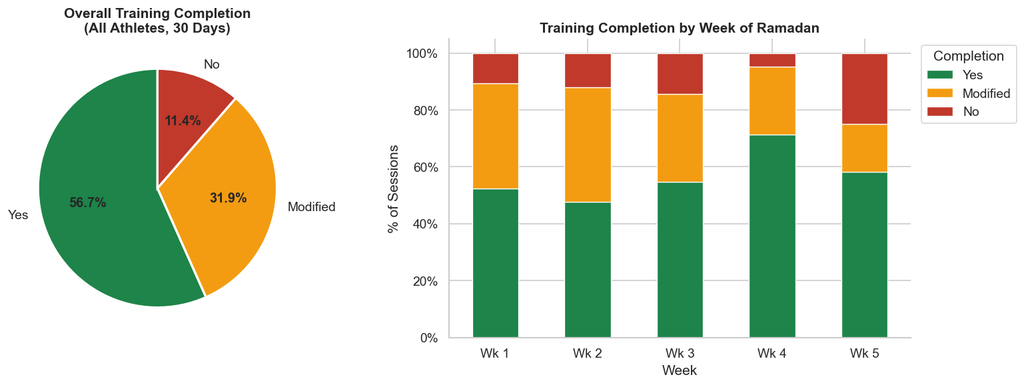

```
→ Saved fig_completion_overview.png
```

```python
fig, axes = plt.subplots(1, 2, figsize=(14, 5))

# ── Pie chart: overall completion distribution ────────────────────────────────
completion_counts = df['completion'].value_counts()
colors_pie = [RAMADAN_PALETTE['green'], RAMADAN_PALETTE['accent'], RAMADAN_PALETTE['secondary']]
wedges, texts, autotexts = axes[0].pie(
    completion_counts,
    labels=completion_counts.index,
    autopct='%1.1f%%',
    colors=colors_pie,
    startangle=90,
    wedgeprops={'edgecolor': 'white', 'linewidth': 2}
)
for at in autotexts:
    at.set_fontsize(12)
    at.set_fontweight('bold')
axes[0].set_title('Overall Training Completion\n(All Athletes, 30 Days)', fontweight='bold')

# ── Stacked bar: completion by week ──────────────────────────────────────────
week_comp = (
    df.groupby(['week', 'completion'])
    .size()
    .unstack(fill_value=0)
    .reindex(columns=['Yes', 'Modified', 'No'])
)
week_comp_pct = week_comp.div(week_comp.sum(axis=1), axis=0) * 100
week_comp_pct.plot(
    kind='bar', stacked=True, ax=axes[1],
    color=[RAMADAN_PALETTE['green'], RAMADAN_PALETTE['accent'], RAMADAN_PALETTE['secondary']],
    edgecolor='white', linewidth=0.8
)
axes[1].set_title('Training Completion by Week of Ramadan', fontweight='bold')
axes[1].set_xlabel('Week')
axes[1].set_ylabel('% of Sessions')
axes[1].set_xticklabels([f'Wk {w}' for w in week_comp_pct.index], rotation=0)
axes[1].legend(title='Completion', bbox_to_anchor=(1.01, 1), loc='upper left')
axes[1].yaxis.set_major_formatter(mticker.PercentFormatter())

plt.tight_layout()
plt.savefig('fig_completion_overview.png', bbox_inches='tight')
plt.show()
print('→ Saved fig_completion_overview.png')
```

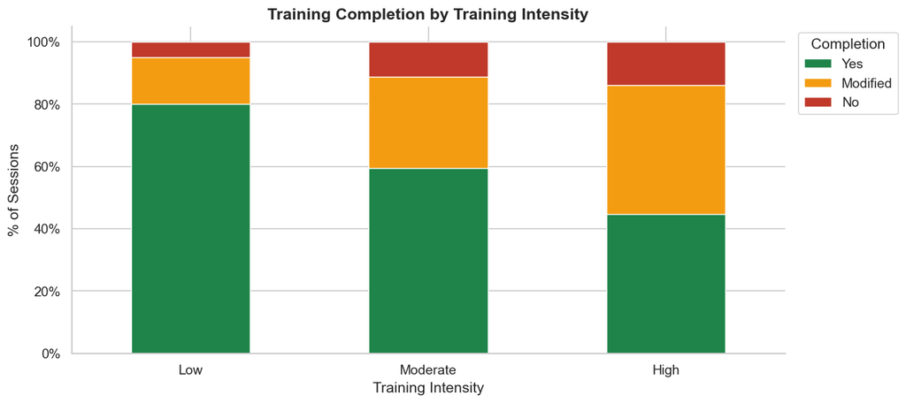

```python
fig, ax = plt.subplots(figsize=(11, 5))

int_comp = (
    df.groupby(['intensity', 'completion'])
    .size()
    .unstack(fill_value=0)
    .reindex(columns=['Yes', 'Modified', 'No'])
)
int_comp_pct = int_comp.div(int_comp.sum(axis=1), axis=0) * 100

# reorder intensities
int_comp_pct = int_comp_pct.reindex(['Low', 'Moderate', 'High'])

int_comp_pct.plot(
    kind='bar', stacked=True, ax=ax,
    color=[RAMADAN_PALETTE['green'], RAMADAN_PALETTE['accent'], RAMADAN_PALETTE['secondary']],
    edgecolor='white', linewidth=0.8, width=0.5
)
ax.set_title('Training Completion by Training Intensity', fontweight='bold', fontsize=14)
ax.set_xlabel('Training Intensity')
ax.set_ylabel('% of Sessions')
ax.set_xticklabels(['Low', 'Moderate', 'High'], rotation=0)
ax.legend(title='Completion', bbox_to_anchor=(1.01, 1), loc='upper left')
ax.yaxis.set_major_formatter(mticker.PercentFormatter())
plt.tight_layout()
plt.savefig('fig_completion_intensity.png', bbox_inches='tight')
plt.show()
```

## 4. Energy & Recovery Trends Over Time

> **Key question:** Do energy and recovery scores decline, improve, or fluctuate across the 30-day fast?

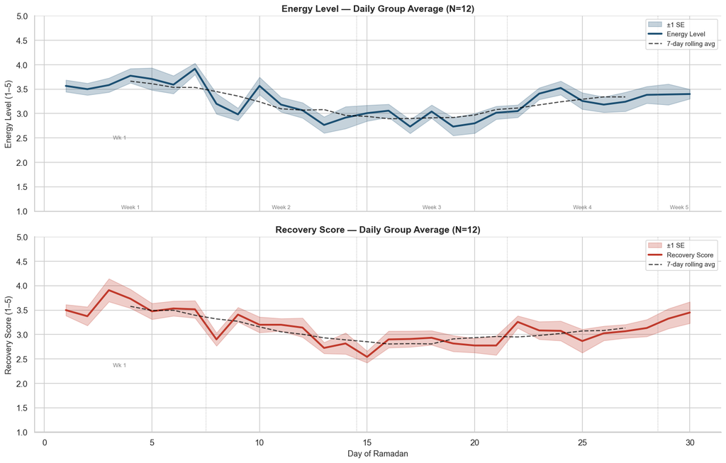

```python
daily = df.groupby('day').agg(
    energy_mean=('energy', 'mean'),
    energy_se=('energy', lambda x: x.sem()),
    recovery_mean=('recovery', 'mean'),
    recovery_se=('recovery', lambda x: x.sem()),
    perf_mean=('perf_score', 'mean'),
).reset_index()

fig, axes = plt.subplots(2, 1, figsize=(14, 9), sharex=True)

for ax, metric, se_col, color, label in [
    (axes[0], 'energy_mean',   'energy_se',   RAMADAN_PALETTE['primary'],    'Energy Level'),
    (axes[1], 'recovery_mean', 'recovery_se', RAMADAN_PALETTE['secondary'],  'Recovery Score'),
]:
    ax.fill_between(
        daily['day'],
        daily[metric] - daily[se_col],
        daily[metric] + daily[se_col],
        alpha=0.25, color=color, label='±1 SE'
    )
    ax.plot(daily['day'], daily[metric], color=color, lw=2.5, label=label)

    # rolling 7-day average
    rolling = daily[metric].rolling(7, center=True).mean()
    ax.plot(daily['day'], rolling, color='black', lw=1.5, ls='--', alpha=0.7, label='7-day rolling avg')

    # week dividers
    for wk_end in [7, 14, 21, 28]:
        ax.axvline(wk_end + 0.5, color='gray', lw=0.8, ls=':', alpha=0.7)
    ax.text(3.5,  ax.get_ylim()[0], 'Wk 1', fontsize=8, color='gray', ha='center')

    ax.set_ylabel(f'{label} (1–5)', fontsize=11)
    ax.set_ylim(1, 5)
    ax.legend(loc='upper right', fontsize=9)
    ax.set_title(f'{label} — Daily Group Average (N=12)', fontweight='bold')

axes[1].set_xlabel('Day of Ramadan', fontsize=11)

# add week labels
for i, (start, end) in enumerate([(1,7),(8,14),(15,21),(22,28),(29,30)], 1):
    mid = (start + end) / 2
    axes[0].text(mid, 1.05, f'Week {i}', fontsize=7.5, color='gray', ha='center')

plt.tight_layout()
plt.savefig('fig_energy_recovery_trends.png', bbox_inches='tight')
plt.show()
```

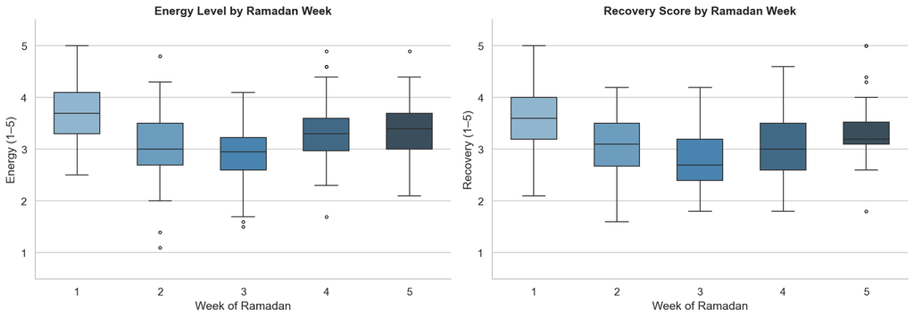

```python
fig, axes = plt.subplots(1, 2, figsize=(14, 5))

for ax, metric, title in [
    (axes[0], 'energy',   'Energy Level by Ramadan Week'),
    (axes[1], 'recovery', 'Recovery Score by Ramadan Week'),
]:
    sns.boxplot(
        data=df, x='week', y=metric, ax=ax,
        palette=sns.color_palette('Blues_d', 5),
        width=0.55, fliersize=3
    )
    ax.set_title(title, fontweight='bold')
    ax.set_xlabel('Week of Ramadan')
    ax.set_ylabel(f'{metric.capitalize()} (1–5)')
    ax.set_ylim(0.5, 5.5)

plt.tight_layout()
plt.savefig('fig_weekly_boxplots.png', bbox_inches='tight')
plt.show()
```

```python
print('=== LINEAR REGRESSION: Day → Energy & Recovery ===')
for metric in ['energy', 'recovery']:
    slope, intercept, r, p, se = stats.linregress(df['day'], df[metric])
    direction = '📉 declining' if slope < 0 else '📈 improving'
    sig       = '✅ significant' if p < 0.05 else '❌ not significant'
    print(f'\n  {metric.upper()}')
    print(f'    slope = {slope:.4f}  |  R² = {r**2:.3f}  |  p = {p:.4f}')
    print(f'    Trend: {direction}  |  Statistical significance: {sig}')
```

```
=== LINEAR REGRESSION: Day → Energy & Recovery ===

  ENERGY
    slope = -0.0125  |  R² = 0.030  |  p = 0.0010
    Trend: 📉 declining  |  Statistical significance: ✅ significant

  RECOVERY
    slope = -0.0168  |  R² = 0.049  |  p = 0.0000
    Trend: 📉 declining  |  Statistical significance: ✅ significant
```

## 5. Hydration & Sleep Impact

> **Key question:** Does being dehydrated or under-slept meaningfully hurt energy and recovery scores?

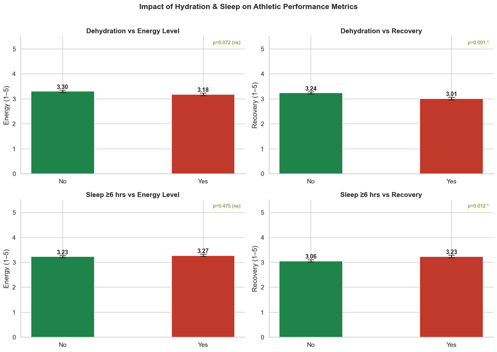

```python
fig, axes = plt.subplots(2, 2, figsize=(13, 9))

combos = [
    ('dehydrated', 'energy',   'Dehydration vs Energy Level',   axes[0, 0]),
    ('dehydrated', 'recovery', 'Dehydration vs Recovery',       axes[0, 1]),
    ('sleep_6hr',  'energy',   'Sleep ≥6 hrs vs Energy Level',  axes[1, 0]),
    ('sleep_6hr',  'recovery', 'Sleep ≥6 hrs vs Recovery',      axes[1, 1]),
]

for cat_col, metric, title, ax in combos:
    grp = df.groupby(cat_col)[metric].agg(['mean', 'sem']).reset_index()
    colors = [RAMADAN_PALETTE['green'], RAMADAN_PALETTE['secondary']] if grp[cat_col].iloc[0] == 'No' \
             else [RAMADAN_PALETTE['secondary'], RAMADAN_PALETTE['green']]
    bars = ax.bar(grp[cat_col], grp['mean'], yerr=grp['sem'],
                  color=colors, edgecolor='white', capsize=6, width=0.45)
    for bar in bars:
        h = bar.get_height()
        ax.text(bar.get_x() + bar.get_width() / 2., h + 0.05,
                f'{h:.2f}', ha='center', va='bottom', fontsize=11, fontweight='bold')
    ax.set_title(title, fontweight='bold')
    ax.set_ylabel(f'{metric.capitalize()} (1–5)')
    ax.set_ylim(0, 5.5)

    # T-test annotation
    groups = [df[df[cat_col] == lbl][metric].dropna() for lbl in grp[cat_col]]
    t_stat, p_val = stats.ttest_ind(*groups)
    sig_text = f'p={p_val:.3f} {"*" if p_val < 0.05 else "(ns)"}'
    ax.text(0.98, 0.97, sig_text, transform=ax.transAxes,
            ha='right', va='top', fontsize=9, color='dimgray',
            bbox=dict(boxstyle='round,pad=0.3', facecolor='lightyellow', alpha=0.7))

plt.suptitle('Impact of Hydration & Sleep on Athletic Performance Metrics',
             fontweight='bold', fontsize=14, y=1.01)
plt.tight_layout()
plt.savefig('fig_hydration_sleep.png', bbox_inches='tight')
plt.show()
```

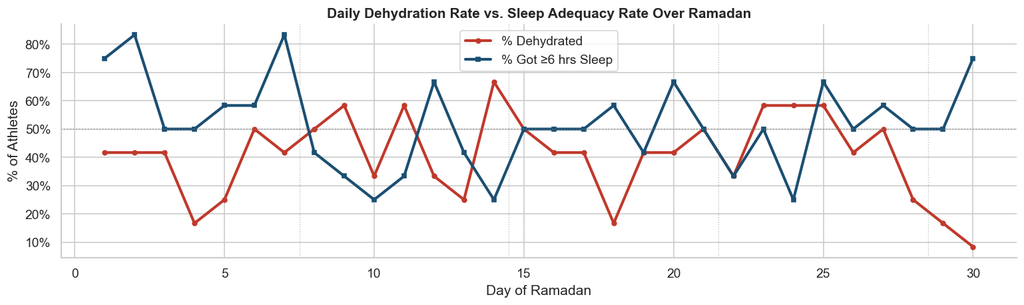

```python
daily_dh = df.groupby('day').agg(
    dehydration_rate=('dehydrated_bool', 'mean'),
    sleep_rate=('sleep_bool', 'mean')
).reset_index()

fig, ax = plt.subplots(figsize=(13, 4))
ax.plot(daily_dh['day'], daily_dh['dehydration_rate'] * 100,
        color=RAMADAN_PALETTE['secondary'], lw=2.5, label='% Dehydrated', marker='o', ms=4)
ax.plot(daily_dh['day'], daily_dh['sleep_rate'] * 100,
        color=RAMADAN_PALETTE['primary'], lw=2.5, label='% Got ≥6 hrs Sleep', marker='s', ms=4)
ax.axhline(50, color='gray', ls=':', lw=1, alpha=0.6)
for wk_end in [7, 14, 21, 28]:
    ax.axvline(wk_end + 0.5, color='gray', lw=0.8, ls=':', alpha=0.5)
ax.set_title('Daily Dehydration Rate vs. Sleep Adequacy Rate Over Ramadan', fontweight='bold')
ax.set_xlabel('Day of Ramadan')
ax.set_ylabel('% of Athletes')
ax.yaxis.set_major_formatter(mticker.PercentFormatter())
ax.legend()
plt.tight_layout()
plt.savefig('fig_dehydration_sleep_timeline.png', bbox_inches='tight')
plt.show()
```

## 6. Sport-by-Sport Breakdown

> **Key question:** Which sports saw the biggest performance drop — or held up best — during Ramadan?

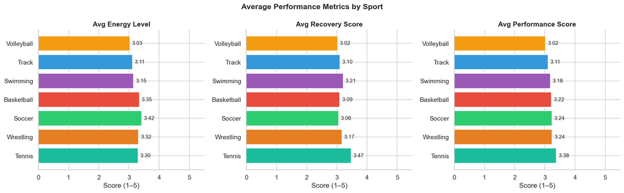

```
            avg_energy  avg_recovery  avg_perf  pct_dehydrated  pct_full  \
sport
Tennis           3.297         3.473     3.385           0.267     0.533
Wrestling        3.317         3.168     3.242           0.500     0.583
Soccer           3.422         3.057     3.239           0.350     0.633
Basketball       3.347         3.093     3.220           0.433     0.617
Swimming         3.153         3.205     3.179           0.333     0.500
Track            3.112         3.103     3.108           0.417     0.533
Volleyball       3.027         3.020     3.023           0.533     0.533

            pct_missed
sport
Tennis           0.267
Wrestling        0.100
Soccer           0.067
Basketball       0.133
Swimming         0.117
Track            0.083
Volleyball       0.100
```

```python
sport_agg = (
    df.groupby('sport')
    .agg(
        avg_energy   =('energy',          'mean'),
        avg_recovery =('recovery',         'mean'),
        avg_perf     =('perf_score',       'mean'),
        pct_dehydrated=('dehydrated_bool', 'mean'),
        pct_full     =('completed_full',   'mean'),
        pct_missed   =('missed_session',   'mean'),
    )
    .round(3)
    .sort_values('avg_perf', ascending=False)
)

fig, axes = plt.subplots(1, 3, figsize=(16, 5))

for ax, col, title in [
    (axes[0], 'avg_energy',   'Avg Energy Level'),
    (axes[1], 'avg_recovery', 'Avg Recovery Score'),
    (axes[2], 'avg_perf',     'Avg Performance Score'),
]:
    colors = [SPORT_COLORS[s] for s in sport_agg.index]
    bars = ax.barh(sport_agg.index, sport_agg[col], color=colors, edgecolor='white')
    ax.bar_label(bars, fmt='%.2f', padding=4, fontsize=10)
    ax.set_title(title, fontweight='bold')
    ax.set_xlim(0, 5.5)
    ax.set_xlabel('Score (1–5)')

plt.suptitle('Average Performance Metrics by Sport', fontweight='bold', fontsize=14)
plt.tight_layout()
plt.savefig('fig_sport_comparison.png', bbox_inches='tight')
plt.show()
print(sport_agg)
```

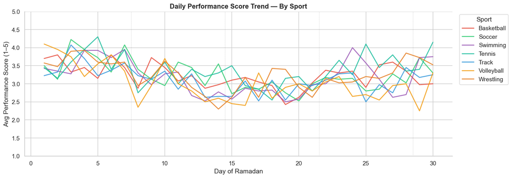

```python
sport_daily = df.groupby(['sport', 'day'])['perf_score'].mean().reset_index()

fig, ax = plt.subplots(figsize=(14, 5))
for sport, grp in sport_daily.groupby('sport'):
    ax.plot(grp['day'], grp['perf_score'], label=sport,
            color=SPORT_COLORS[sport], lw=1.8, alpha=0.85)

for wk_end in [7, 14, 21, 28]:
    ax.axvline(wk_end + 0.5, color='gray', lw=0.8, ls=':', alpha=0.5)

ax.set_title('Daily Performance Score Trend — By Sport', fontweight='bold', fontsize=13)
ax.set_xlabel('Day of Ramadan')
ax.set_ylabel('Avg Performance Score (1–5)')
ax.set_ylim(1, 5)
ax.legend(title='Sport', bbox_to_anchor=(1.01, 1), loc='upper left')
plt.tight_layout()
plt.savefig('fig_sport_daily_trends.png', bbox_inches='tight')
plt.show()
```

## 7. Intensity Group Comparisons

> **Key question:** Do athletes training at higher intensities during Ramadan show worse outcomes?

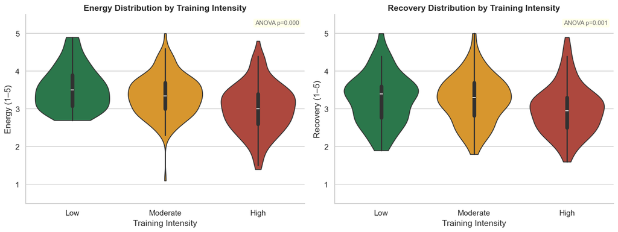

```python
intensity_order = ['Low', 'Moderate', 'High']

fig, axes = plt.subplots(1, 2, figsize=(13, 5))

for ax, metric in [(axes[0], 'energy'), (axes[1], 'recovery')]:
    sns.violinplot(
        data=df, x='intensity', y=metric, order=intensity_order,
        palette=[RAMADAN_PALETTE['green'], RAMADAN_PALETTE['accent'], RAMADAN_PALETTE['secondary']],
        inner='box', cut=0, ax=ax
    )
    ax.set_title(f'{metric.capitalize()} Distribution by Training Intensity', fontweight='bold')
    ax.set_xlabel('Training Intensity')
    ax.set_ylabel(f'{metric.capitalize()} (1–5)')
    ax.set_ylim(0.5, 5.5)

    # ANOVA
    groups = [df[df['intensity'] == i][metric].dropna() for i in intensity_order]
    f_stat, p_val = stats.f_oneway(*groups)
    ax.text(0.98, 0.97, f'ANOVA p={p_val:.3f}', transform=ax.transAxes,
            ha='right', va='top', fontsize=9, color='dimgray',
            bbox=dict(boxstyle='round,pad=0.3', facecolor='lightyellow', alpha=0.7))

plt.tight_layout()
plt.savefig('fig_intensity_violin.png', bbox_inches='tight')
plt.show()
```

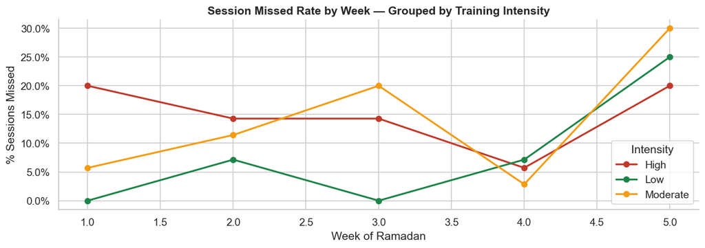

```python
int_miss = df.groupby(['intensity', 'week'])['missed_session'].mean().reset_index()

fig, ax = plt.subplots(figsize=(11, 4))
for intensity, grp in int_miss.groupby('intensity'):
    color = {'Low': RAMADAN_PALETTE['green'], 'Moderate': RAMADAN_PALETTE['accent'],
             'High': RAMADAN_PALETTE['secondary']}[intensity]
    ax.plot(grp['week'], grp['missed_session'] * 100, marker='o', lw=2,
            color=color, label=intensity)

ax.set_title('Session Missed Rate by Week — Grouped by Training Intensity', fontweight='bold')
ax.set_xlabel('Week of Ramadan')
ax.set_ylabel('% Sessions Missed')
ax.yaxis.set_major_formatter(mticker.PercentFormatter())
ax.legend(title='Intensity')
plt.tight_layout()
plt.savefig('fig_intensity_missed_rate.png', bbox_inches='tight')
plt.show()
```

## 8. Gender Comparison

> **Key question:** Are there meaningful differences between male and female athletes in how they manage fasting and training?

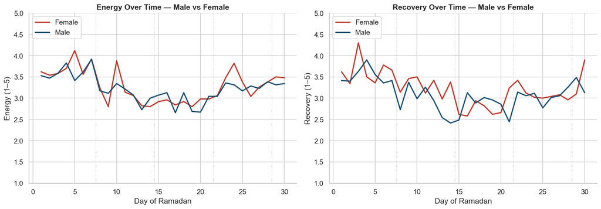

```
=== GENDER SUMMARY ===
        avg_energy  avg_recovery  pct_dehydrated  pct_slept  pct_missed
gender
Female       3.286         3.223           0.347      0.473        0.12
Male         3.228         3.090           0.448      0.548        0.11
```

```python
gender_daily = df.groupby(['gender', 'day']).agg(
    energy=('energy', 'mean'),
    recovery=('recovery', 'mean')
).reset_index()

fig, axes = plt.subplots(1, 2, figsize=(14, 5))

for ax, metric in [(axes[0], 'energy'), (axes[1], 'recovery')]:
    for gender, grp in gender_daily.groupby('gender'):
        color = RAMADAN_PALETTE['primary'] if gender == 'Male' else RAMADAN_PALETTE['secondary']
        ax.plot(grp['day'], grp[metric], label=gender, color=color, lw=2)
    for wk_end in [7, 14, 21, 28]:
        ax.axvline(wk_end + 0.5, color='gray', lw=0.8, ls=':', alpha=0.5)
    ax.set_title(f'{metric.capitalize()} Over Time — Male vs Female', fontweight='bold')
    ax.set_xlabel('Day of Ramadan')
    ax.set_ylabel(f'{metric.capitalize()} (1–5)')
    ax.set_ylim(1, 5)
    ax.legend()

plt.tight_layout()
plt.savefig('fig_gender_trends.png', bbox_inches='tight')
plt.show()

# Summary table
gender_summary = df.groupby('gender').agg(
    avg_energy   =('energy',          'mean'),
    avg_recovery =('recovery',        'mean'),
    pct_dehydrated=('dehydrated_bool','mean'),
    pct_slept    =('sleep_bool',      'mean'),
    pct_missed   =('missed_session',  'mean'),
).round(3)
print('\n=== GENDER SUMMARY ===')
print(gender_summary)
```

## 9. Individual Athlete Profiles

> A dashboard for each athlete showing their full 30-day arc of performance.

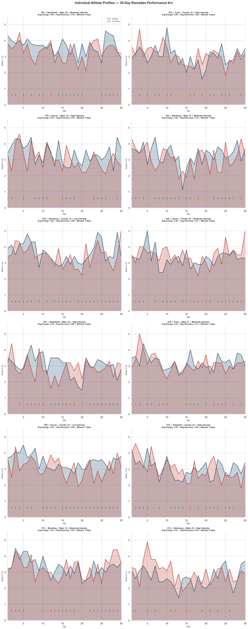

```python
COMPLETION_COLORS = {'Yes': RAMADAN_PALETTE['green'],
                     'Modified': RAMADAN_PALETTE['accent'],
                     'No': RAMADAN_PALETTE['secondary']}

fig, axes = plt.subplots(6, 2, figsize=(16, 40))
axes = axes.flatten()

for idx, pid in enumerate(sorted(df['participant_id'].unique())):
    p = df[df['participant_id'] == pid].copy()
    ax = axes[idx]

    sport    = p['sport'].iloc[0]
    gender   = p['gender'].iloc[0]
    age      = p['age'].iloc[0]
    intensity= p['intensity'].iloc[0]

    ax.fill_between(p['day'], p['energy'],   alpha=0.25,
                    color=RAMADAN_PALETTE['primary'],   label='Energy')
    ax.fill_between(p['day'], p['recovery'], alpha=0.25,
                    color=RAMADAN_PALETTE['secondary'], label='Recovery')
    ax.plot(p['day'], p['energy'],   color=RAMADAN_PALETTE['primary'],   lw=1.8)
    ax.plot(p['day'], p['recovery'], color=RAMADAN_PALETTE['secondary'], lw=1.8)

    # mark completion status as scatter
    for status, grp in p.groupby('completion'):
        ax.scatter(grp['day'], [0.6] * len(grp), color=COMPLETION_COLORS[status],
                   marker='|', s=80, linewidths=2, zorder=5)

    ax.set_ylim(0, 5.5)
    ax.set_xlim(1, 30)
    ax.set_xlabel('Day', fontsize=9)
    ax.set_ylabel('Score (1–5)', fontsize=9)
    ax.set_title(
        f'{pid}  |  {sport}  |  {gender}, {age}  |  {intensity} intensity\n'
        f'Avg Energy: {p.energy.mean():.2f}  |  Avg Recovery: {p.recovery.mean():.2f}  '
        f'|  Missed: {int(p.missed_session.sum())} days',
        fontsize=9, fontweight='bold'
    )
    if idx == 0:
        ax.legend(fontsize=8, loc='upper right')

plt.suptitle('Individual Athlete Profiles — 30-Day Ramadan Performance Arc',
             fontweight='bold', fontsize=15, y=1.002)
plt.tight_layout()
plt.savefig('fig_individual_profiles.png', bbox_inches='tight')
plt.show()
```

## 10. Correlation Heatmap & Key Insights Summary

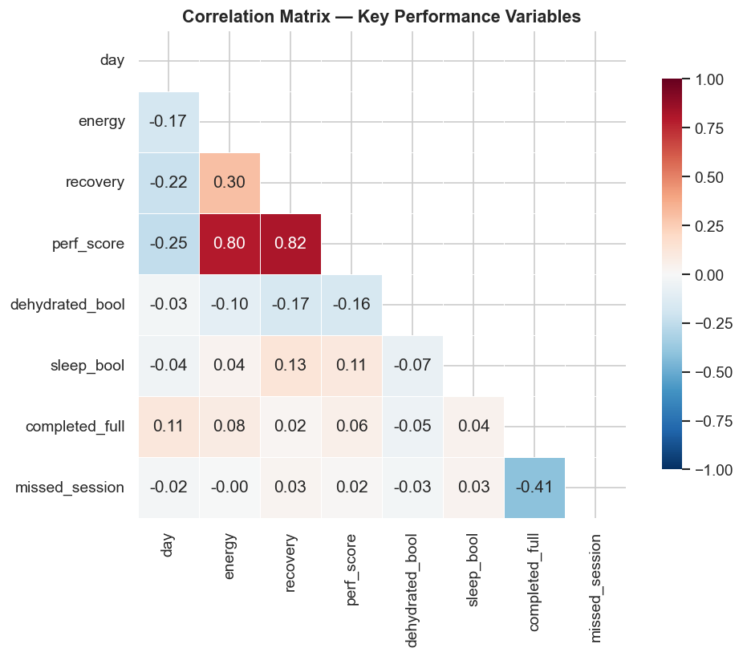

```python
corr_df = df[['day', 'energy', 'recovery', 'perf_score',
              'dehydrated_bool', 'sleep_bool', 'completed_full', 'missed_session']].copy()
corr_df = corr_df.astype(float)

corr_matrix = corr_df.corr()

fig, ax = plt.subplots(figsize=(9, 7))
mask = np.triu(np.ones_like(corr_matrix, dtype=bool))
sns.heatmap(
    corr_matrix, mask=mask, annot=True, fmt='.2f',
    cmap='RdBu_r', center=0, vmin=-1, vmax=1,
    square=True, linewidths=0.5, ax=ax,
    cbar_kws={'shrink': 0.8}
)
ax.set_title('Correlation Matrix — Key Performance Variables', fontweight='bold', fontsize=13)
plt.tight_layout()
plt.savefig('fig_correlation_heatmap.png', bbox_inches='tight')
plt.show()
```

```python
print('=' * 60)
print('  📋 KEY INSIGHTS — RAMADAN ATHLETIC PERFORMANCE STUDY')
print('=' * 60)

# 1. Overall averages
print(f'\n1. OVERALL AVERAGES')
print(f'   Avg Energy Level  : {df.energy.mean():.2f} / 5.0')
print(f'   Avg Recovery Score: {df.recovery.mean():.2f} / 5.0')
print(f'   Avg Perf Score    : {df.perf_score.mean():.2f} / 5.0')

# 2. Training completion
comp_pct = df['completion'].value_counts(normalize=True) * 100
print(f'\n2. TRAINING COMPLETION')
for k, v in comp_pct.items():
    print(f'   {k:12s}: {v:.1f}%')

# 3. Hydration & sleep
dh_rate   = df['dehydrated_bool'].mean() * 100
sleep_rate = df['sleep_bool'].mean() * 100
print(f'\n3. WELLNESS METRICS')
print(f'   Reported dehydration : {dh_rate:.1f}% of athlete-days')
print(f'   Got ≥6 hrs sleep     : {sleep_rate:.1f}% of athlete-days')

# 4. Best & worst performers
print(f'\n4. BEST & WORST PERFORMING SPORTS (avg performance score)')
sport_perf = df.groupby('sport')['perf_score'].mean().sort_values(ascending=False)
print(f'   🥇 Best : {sport_perf.index[0]} ({sport_perf.iloc[0]:.2f})')
print(f'   🥈 2nd  : {sport_perf.index[1]} ({sport_perf.iloc[1]:.2f})')
print(f'   🔴 Worst: {sport_perf.index[-1]} ({sport_perf.iloc[-1]:.2f})')

# 5. Effect of dehydration
dh_yes = df[df['dehydrated'] == 'Yes']['energy'].mean()
dh_no  = df[df['dehydrated'] == 'No']['energy'].mean()
print(f'\n5. DEHYDRATION IMPACT ON ENERGY')
print(f'   Dehydrated days: {dh_yes:.2f}  |  Hydrated days: {dh_no:.2f}  |  Δ = {dh_no - dh_yes:.2f}')

# 6. Sleep impact
sl_yes = df[df['sleep_6hr'] == 'Yes']['recovery'].mean()
sl_no  = df[df['sleep_6hr'] == 'No']['recovery'].mean()
print(f'\n6. SLEEP IMPACT ON RECOVERY')
print(f'   ≥6 hrs sleep: {sl_yes:.2f}  |  <6 hrs sleep: {sl_no:.2f}  |  Δ = {sl_yes - sl_no:.2f}')

# 7. Trend
slope_e, _, _, p_e, _ = stats.linregress(df['day'], df['energy'])
slope_r, _, _, p_r, _ = stats.linregress(df['day'], df['recovery'])
print(f'\n7. 30-DAY TREND (linear regression slope per day)')
print(f'   Energy slope   : {slope_e:+.4f}  (p={p_e:.4f})')
print(f'   Recovery slope : {slope_r:+.4f}  (p={p_r:.4f})')

print()
print('=' * 60)
```

```
============================================================
  📋 KEY INSIGHTS — RAMADAN ATHLETIC PERFORMANCE STUDY
============================================================

1. OVERALL AVERAGES
   Avg Energy Level  : 3.25 / 5.0
   Avg Recovery Score: 3.15 / 5.0
   Avg Perf Score    : 3.20 / 5.0

2. TRAINING COMPLETION
   Yes         : 56.7%
   Modified    : 31.9%
   No          : 11.4%

3. WELLNESS METRICS
   Reported dehydration : 40.6% of athlete-days
   Got ≥6 hrs sleep     : 51.7% of athlete-days

4. BEST & WORST PERFORMING SPORTS (avg performance score)
   🥇 Best : Tennis (3.38)
   🥈 2nd  : Wrestling (3.24)
   🔴 Worst: Volleyball (3.02)

5. DEHYDRATION IMPACT ON ENERGY
   Dehydrated days: 3.18  |  Hydrated days: 3.30  |  Δ = 0.12

6. SLEEP IMPACT ON RECOVERY
   ≥6 hrs sleep: 3.23  |  <6 hrs sleep: 3.06  |  Δ = 0.17

7. 30-DAY TREND (linear regression slope per day)
   Energy slope   : -0.0125  (p=0.0010)
   Recovery slope : -0.0168  (p=0.0000)

============================================================
```

## Notes for the App Team

The following derived metrics and data structures from this notebook are recommended as inputs to the app:

- **`perf_score`** — composite average of `energy` and `recovery` (both on 1–5 scale). Simple and explainable.
- **Weekly aggregates** — rolling up to week-level smooths daily noise and is suitable for trend cards.
- **Completion rate** — `Yes / (Yes + Modified + No)` can feed a training adherence gauge.
- **Dehydration & sleep flags** — binary signals that pair well with alert/badge UI patterns.
- **Sport and intensity facets** — users may want to filter dashboards by these dimensions.

All saved chart images (`fig_*.png`) are in the same directory as this notebook.